# Experimenting on Politics

## When should one use experiment

- Well-defined concept
- Clear-stated propositions
- Small-group interaction

## Classical experiment

| Test | Assignment Stim. | Assignment NonStim. |
| --- | --- | --- |
| Pretest | Treatment | Control |
| Posttest | Treatment | Control |

- Do we always need pretest and posttest?
- Do we always need treatment and control groups?
- Double-blind?

## What does randomization bring us?

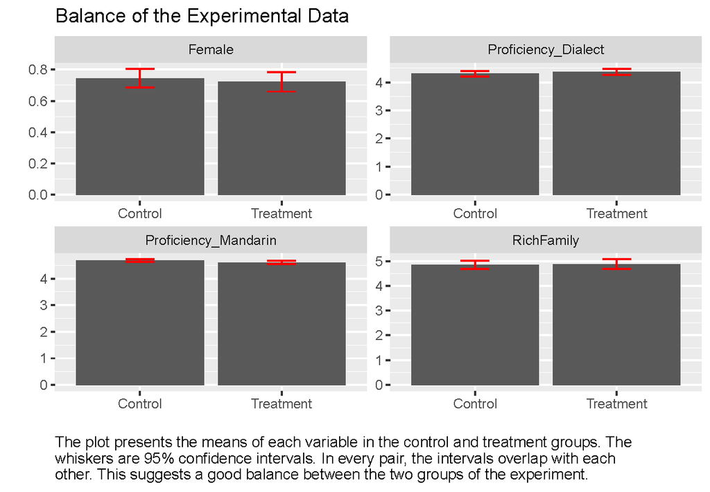

## How about matching?

[figure not shown]

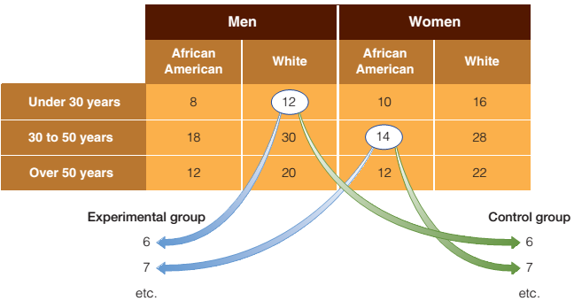

## Validity

"The approximate truth of the inference or knowledge claim."—Morton & Williams (2010, 254)

- Internal Validity: The approximate truth of the inference or knowledge claim *within* a target population studies.
  - Construct validity
  - Causal validity
  - Statistical validity

## External vs. Ecological Validity

- Internal Validity: The approximate truth of the inference or knowledge claim *within* a target population studies.
- External validity: The approximate truth of the inference or knowledge claim *beyond* a target population studies.
- Ecological validity: Whether the methods, materials, and settings of the research are similar to a given target environment.

## Which validity should be concerned?

[figure not shown]

## Which validity should be concerned?

[figure not shown]

## Which validity should be concerned?

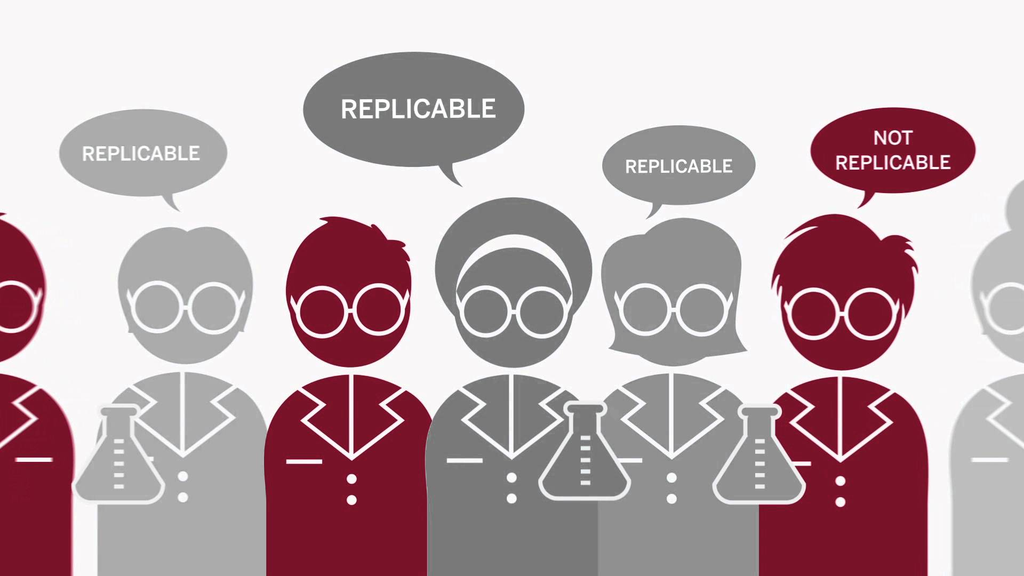

## How do experiments define causality?

- Rubin's causal model:
  - Treatment effect:

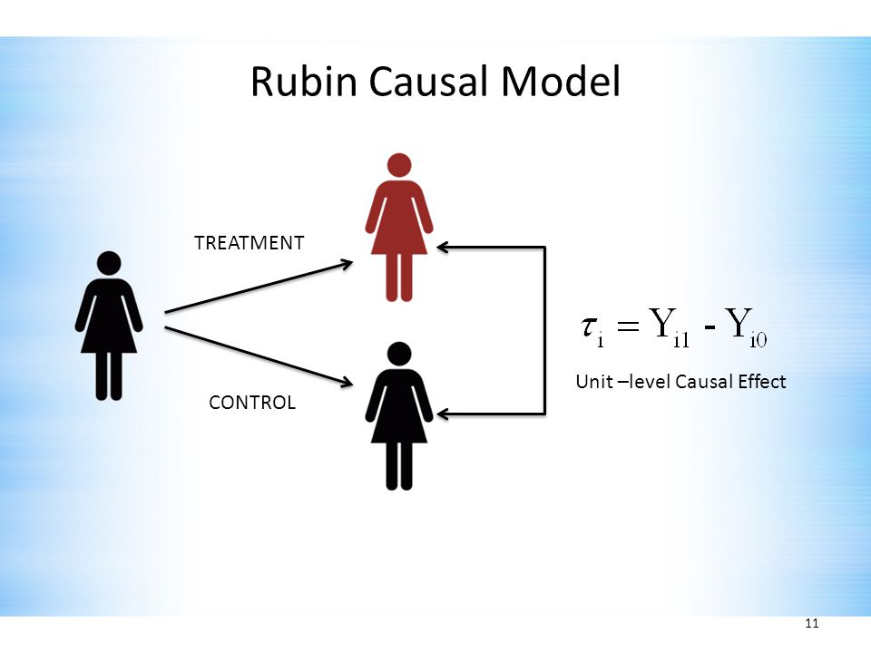

    - ATE: \(E(\tau_i) = E(Y_{i1}) - E(Y_{i0})\)

Averaged treatment effect among the treated

- Why do we care?
- \(E(\tau_i|T_i = 1) = E(Y_{i1}|T_i = 1) - E(Y_{i0}|T_i = 1)\)

## Experimental assumptions

1. Independence
2. Exclusion restriction
3. Stable Unit Treatment Value Assumption (SUTVA)
4. Montonicity
5. Nonzero causal effects of assignment on treatment

## Independence

### Definition

Subject will have the same effect regardless which group they are in.

\[ \begin{aligned} E(Y_{i1}|T_i = 1) =& E(Y_{i1}|T_i = 0);\\ E(Y_{i0}|T_i = 1) =& E(Y_{i0}|T_i = 0). \end{aligned} \]

### Violation

- Nonrandom assignment
- Non-double-blind design

## Exclusion restriction

### Definition

Only treatment can make effects.

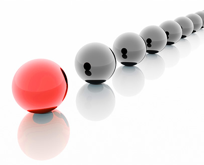

### Violation

- Subjects change their behaviors
- Third party effects

## SUTVA

### Violation (e.g., Herd Effect)

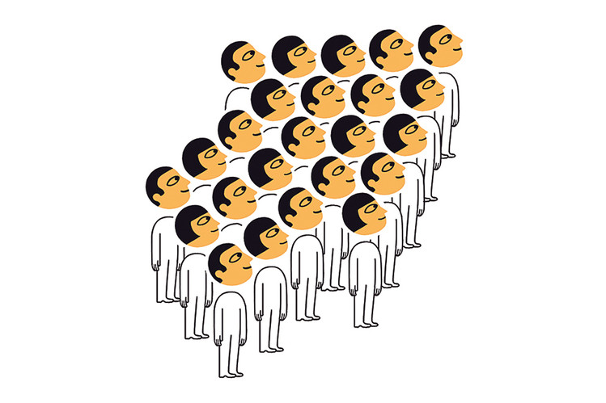

## Montonicity and nonzero causal effects

### Definition

- The probability the subject is treated is at least as great when the subject is in the treatment group as when the subject is in the control group.
- The treatment assignment has an effect on the probability that at least some subjects are treated.

### Violation

- Operation errors
- Third-party effects

## Field Experiment

[video not shown]

- Subject: sample from the target population
- Pro: Ecological validity
- Con: Internal and external validity

## Natural Experiment

[video not shown]

- Stimulation: It just happened.
- Pro: Ecological and external validity
- Con: Internal validity

## Applying the experiment to your research

- Group: 1, 4, 5, 8: field experiment
- Group: 2, 3, 6, 7: natural experiment